# Week Five - Working with Tidy Data

Esteban Aramayo

2021-03-07

## 1. Overview

Create a .CSV file (or optionally, a MySQL database!) that includes all of the information above. Use a “wide” structure similar to how the information appears below, so that tidying and transformations can be used on the data.

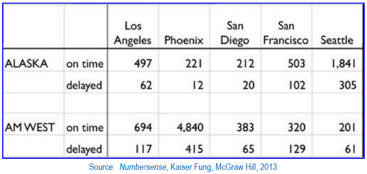

```r
# Libraries to be used
library(tidyverse)
```

## 2. Read untidy data

### 2.1 Read the arrival data

Read the arrival data from your .CSV file

```r
src_file_path <- "C:\\tmp\\Airline_Arrival_Delays.csv"
untidy_flights <- read_csv(src_file_path)
```

### 2.2 Peak at the read data

Take a peak at the data read from the CSV file.

Table: Untidy data for flight arrivals

| Airline | Flight Status | Los Angeles | Phoenix | San Diego | San Francisco | Seattle |
| --- | --- | --- | --- | --- | --- | --- |
| ALASKA | on time | 497 | 221 | 212 | 503 | 1841 |
| ALASKA | delayed | 62 | 12 | 20 | 102 | 305 |
| NA | NA | NA | NA | NA | NA | NA |
| AM WEST | on time | 694 | 4840 | 383 | 320 | 201 |
| AM WEST | delayed | 117 | 415 | 65 | 129 | 61 |

## 3 Tidy the data

Use “tidyr” and “dplyr” as needed to tidy up and transform the data

```r
flights <- untidy_flights %>%
  # remove blank lines
  drop_na() %>%
  # change format from wide to long to tidy up data
  pivot_longer(`Los Angeles`:`Seattle`, names_to = "destination", values_to = "count") %>%
    # rename column names
  rename(airline = Airline, flight_status = `Flight Status`)
```

Show a glimpse of the transformed data.

Table: Tidy data for flight arrivals

| airline | flight_status | destination | count |
| --- | --- | --- | --- |
| ALASKA | on time | Los Angeles | 497 |
| ALASKA | on time | Phoenix | 221 |
| ALASKA | on time | San Diego | 212 |
| ALASKA | on time | San Francisco | 503 |
| ALASKA | on time | Seattle | 1841 |
| ALASKA | delayed | Los Angeles | 62 |
| ALASKA | delayed | Phoenix | 12 |
| ALASKA | delayed | San Diego | 20 |
| ALASKA | delayed | San Francisco | 102 |
| ALASKA | delayed | Seattle | 305 |

## 4 Perform data analysis

Perform data analysis to compare the arrival delays for the two airlines.

### 4.1 Build list of delayed flights

```r
delayed_flights <- flights %>%
  filter(flight_status == "delayed")
```

### 4.2 Overall delays per Airline

Which airline has the most overall delays and which one the least?

```r
by_airline <- delayed_flights %>%
  group_by(airline) %>%
  summarise(total_count = sum(count)) %>%
  arrange(desc(total_count))
```

Overall, **“AM West”** airline has the **highest** number of delays compared to **“ALASKA”**, which has the **lowest**.

Table: Total delays per airline

| airline | total_count |
| --- | --- |
| AM WEST | 787 |
| ALASKA | 501 |

We can see the discrepancy between each airline’s delays graphically

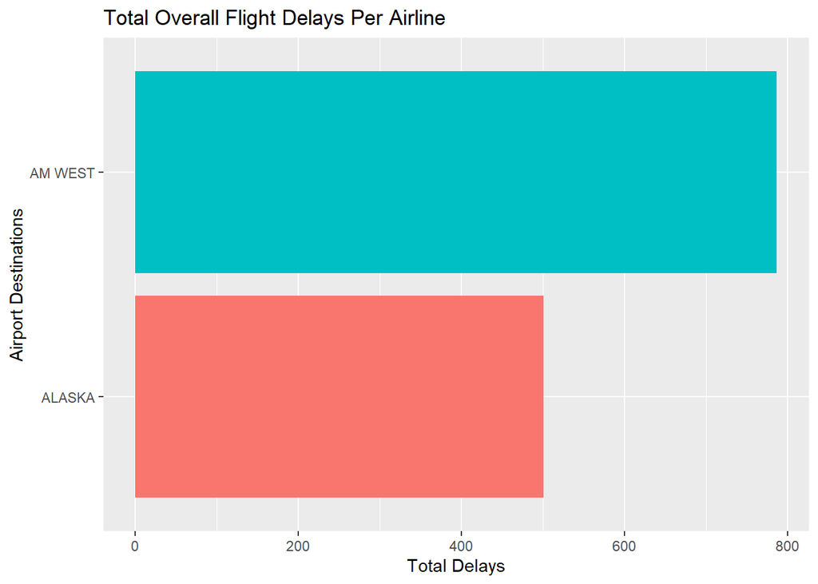

```r
ggplot(by_airline, aes(x = airline, y = total_count, fill = airline)) +
  geom_bar(stat = "identity", position = "dodge") +
  coord_flip() +
  ggtitle("Total Overall Flight Delays Per Airline") +
  labs(x = "Airport Destinations", y = "Total Delays") +
  theme(legend.position = "none")
```

### 4.3 Delays per destination and airline

Which airport destinations had the most and least delays?

```r
by_destination <- delayed_flights %>%
  group_by(destination, airline) %>%
   summarise(total_count = sum(count)) %>%
   arrange(desc(total_count))
```

Overall, the **Phoenix** destination has **highest** number of delays (**“AM West”** airline) as well as the **lowest** number of delays (*“ALASKA”* airline).

Table: Total delays per destination per airline in descending order

| destination | airline | total_count |
| --- | --- | --- |
| Phoenix | AM WEST | 415 |
| Seattle | ALASKA | 305 |
| San Francisco | AM WEST | 129 |
| Los Angeles | AM WEST | 117 |
| San Francisco | ALASKA | 102 |
| San Diego | AM WEST | 65 |
| Los Angeles | ALASKA | 62 |
| Seattle | AM WEST | 61 |
| San Diego | ALASKA | 20 |
| Phoenix | ALASKA | 12 |

Below is the graphical representation of delays per destination in descending order.

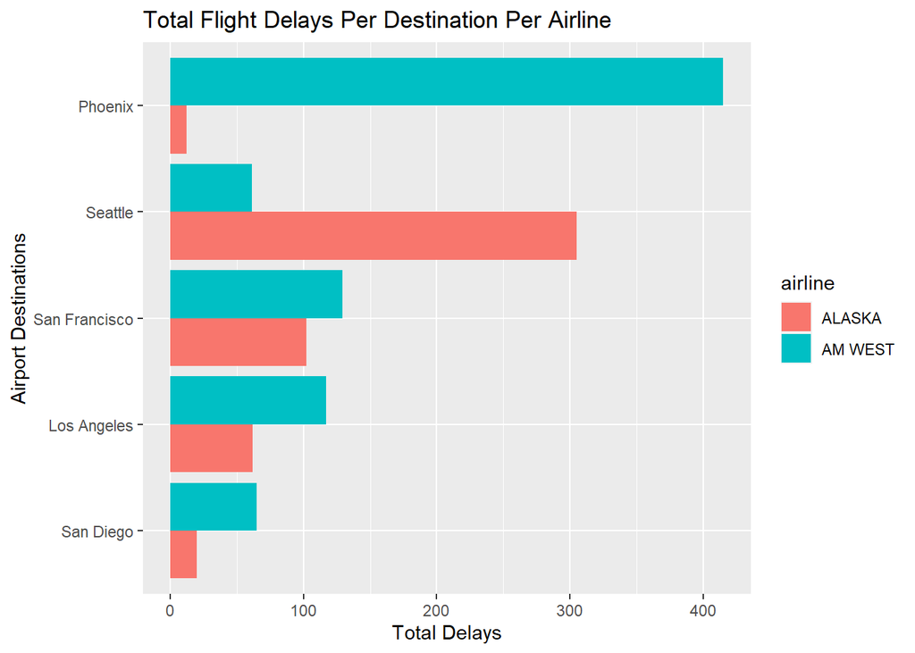

```r
ggplot(by_destination, aes(x = reorder(destination, total_count), y = total_count, fill = airline)) +
  geom_bar(stat = "identity", position = "dodge") +
  coord_flip() +
  ggtitle("Total Flight Delays Per Destination Per Airline") +
  labs(x = "Airport Destinations", y = "Total Delays")
```

## 5. Conclusion

It was demonstrated that the packages “tidyr” and “dplyr” can be extremely useful to tidy up and transform the data.